# Atividade1

## Execricio 1

### ITEM (a): Função de densidade correspondente à CDF do slide 15

A CDF da distribuição de Morgenstern bivariada com marginais Gamma é:

$$F_{X,Y}(x,y) = F_X(x)\,F_Y(y)\,\big[1 + \rho\{1 - F_X(x)\}\{1 -
F_Y(y)\}\big],$$

onde $F_X \sim \text{Gamma}(\alpha,\theta)$, $F_Y \sim \text{Gamma}(\beta,\theta)$ e $-1 \leqslant \rho \leqslant 1$.

Queremos obter a PDF bivariada:

$$f_{X,Y}(x,y) = \frac{\partial^2 F_{X,Y}}{\partial x\,\partial y}(x,y).$$

Para simplificar, denotamos $u = F_X(x)$ e $v = F_Y(y)$, de modo que:

$$F = u\,v\,\big[1 + \rho(1-u)(1-v)\big].$$

### Passo 1: Expansão do produto

Expandindo os parênteses:

$$\begin{aligned}
F &= u\,v\,\big[1 + \rho(1 - u - v + uv)\big] \\
&= uv + \rho\,uv\,(1 - u - v + uv) \\
&= uv + \rho\big(uv - u^2v - uv^2 + u^2v^2\big).
\end{aligned}$$

### Passo 2: Primeira derivada $\frac{\partial F}{\partial u}$

Derivando termo a termo em relação a $u$:

$$\begin{aligned}
\frac{\partial F}{\partial u}
&= v + \rho\big(v - 2uv - v^2 + 2uv^2\big) \\
&= v + \rho\,v\big(1 - 2u - v + 2uv\big).
\end{aligned}$$

Observe que a expressão entre parênteses se fatoriza:

$$1 - 2u - v + 2uv = (1-2u)(1-v),$$

Logo:

$$\boxed{\frac{\partial F}{\partial u} = v\,\big[1 +
\rho(1-2u)(1-v)\big]}.$$

### Passo 3: Derivada cruzada $\frac{\partial^2 F}{\partial u\,\partial v}$

Derivamos o resultado do Passo 2 em relação a $v$. Como temos um produto de $v$ por uma função de $v$, aplicamos a regra do produto:

$$\begin{aligned}
\frac{\partial^2 F}{\partial u\,\partial v}
&= \frac{\partial}{\partial v}\Big\{v\,\big[1 +
\rho(1-2u)(1-v)\big]\Big\} \\[6pt]
&= 1 \cdot \big[1 + \rho(1-2u)(1-v)\big]
\;+\; v \cdot \big[\rho(1-2u)\cdot(-1)\big] \\[6pt]
&= 1 + \rho(1-2u)(1-v) - \rho\,v(1-2u).
\end{aligned}$$

Colocando $\rho(1-2u)$ em evidência nos dois últimos termos:

$$\begin{aligned}
\frac{\partial^2 F}{\partial u\,\partial v}
&= 1 + \rho(1-2u)\big[(1-v) - v\big] \\
&= 1 + \rho(1-2u)(1 - 2v).
\end{aligned}$$

Portanto:

$$\boxed{\frac{\partial^2 F}{\partial u\,\partial v} = 1 +
\rho(1-2u)(1-2v)}.$$

### Passo 4: Regra da cadeia (retorno às variáveis $x$ e $y$)

Lembrando que $u = F_X(x)$ e $v = F_Y(y)$, a regra da cadeia nos dá:

$$\frac{\partial^2 F}{\partial x\,\partial y}
= \frac{\partial^2 F}{\partial u\,\partial v} \cdot \frac{\partial
u}{\partial x} \cdot \frac{\partial v}{\partial y}.$$

Como $u = F_X(x)$, temos $\frac{\partial u}{\partial x} = f_X(x)$ (a PDF marginal de $X$). Analogamente, $\frac{\partial v}{\partial y} = f_Y(y)$. Substituindo:

$$\boxed{f_{X,Y}(x,y) = f_X(x)\,f_Y(y)\,\big[1 + \rho(1 - 2F_X(x))(1 -
2F_Y(y))\big]},$$

onde as densidades marginais Gamma são:

$$f_X(x) =
\frac{x^{\alpha-1}\,e^{-x/\theta}}{\theta^\alpha\,\Gamma(\alpha)},
\qquad
f_Y(y) = \frac{y^{\beta-1}\,e^{-y/\theta}}{\theta^\beta\,\Gamma(\beta)}.$$

### Verificação

Tomando $\rho = 0$:

$$f_{X,Y}(x,y) = f_X(x)\,f_Y(y)\,\big[1 + 0\big] = f_X(x)\,f_Y(y),$$

que é o produto das marginais, confirmando a independência quando $\rho = 0$.

```r
# --- Funções do modelo ---

# CDF bivariada
cdf_morgenstern <- function(x, y, alpha, beta, theta, rho) {
  u <- pgamma(x, shape = alpha, rate = 1/theta)
  v <- pgamma(y, shape = beta, rate = 1/theta)
  u * v * (1 + rho * (1 - u) * (1 - v))
}

# PDF bivariada
pdf_morgenstern <- function(x, y, alpha, beta, theta, rho) {
  fx <- dgamma(x, shape = alpha, rate = 1/theta)
  fy <- dgamma(y, shape = beta, rate = 1/theta)
  Fx <- pgamma(x, shape = alpha, rate = 1/theta)
  Fy <- pgamma(y, shape = beta, rate = 1/theta)
  fx * fy * (1 + rho * (1 - 2 * Fx) * (1 - 2 * Fy))
}
```

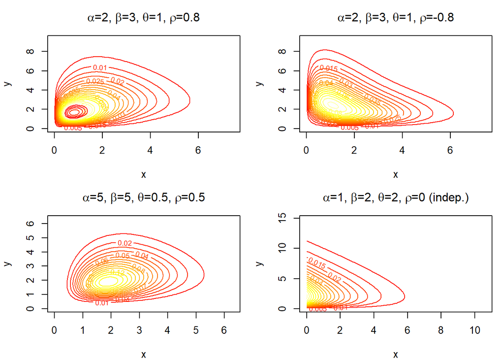

```r
# --- Plots da PDF bivariada ---

# Configuração de grade
n_grid <- 80

# Parâmetros de exemplo
params_list <- list(
  list(alpha = 2, beta = 3, theta = 1, rho = 0.8, title = expression(paste(alpha, "=2, ", beta, "=3, ", theta, "=1, ", rho, "=0.8"))),
  list(alpha = 2, beta = 3, theta = 1, rho = -0.8, title = expression(paste(alpha, "=2, ", beta, "=3, ", theta, "=1, ", rho, "=-0.8"))),
  list(alpha = 5, beta = 5, theta = 0.5, rho = 0.5, title = expression(paste(alpha, "=5, ", beta, "=5, ", theta, "=0.5, ", rho, "=0.5"))),
  list(alpha = 1, beta = 2, theta = 2, rho = 0, title = expression(paste(alpha, "=1, ", beta, "=2, ", theta, "=2, ", rho, "=0 (indep.)")))
)

# Plot: contornos da PDF bivariada
#pdf("plots_item_a.pdf", width = 12, height = 10)
par(mfrow = c(2, 2), mar = c(4, 4, 3, 1))

for (p in params_list) {
  xmax <- qgamma(0.995, shape = p$alpha, rate = 1/p$theta)
  ymax <- qgamma(0.995, shape = p$beta, rate = 1/p$theta)

  x_seq <- seq(0.01, xmax, length.out = n_grid)
  y_seq <- seq(0.01, ymax, length.out = n_grid)

  z_mat <- outer(x_seq, y_seq, function(x, y) {
    mapply(pdf_morgenstern, x, y,
           MoreArgs = list(alpha = p$alpha, beta = p$beta,
                           theta = p$theta, rho = p$rho))
  })

  contour(x_seq, y_seq, z_mat, nlevels = 20,
          xlab = "x", ylab = "y",
          main = p$title, col = heat.colors(20))
  title(sub = "Contornos da PDF bivariada", cex.sub = 0.8)
}
```

```r
#dev.off()
```

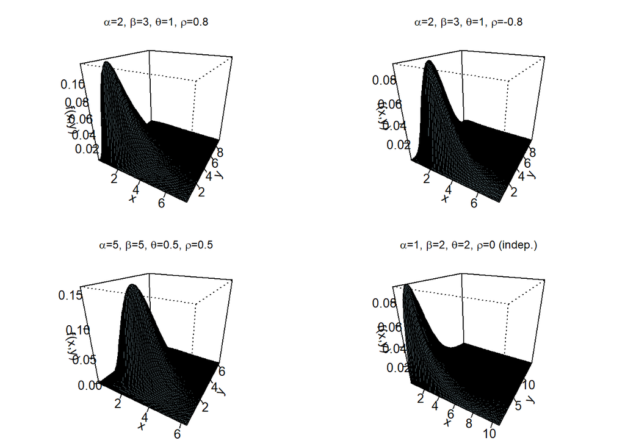

```r
# Plot 3D (perspectiva)
#pdf("plots_item_a_3d.pdf", width = 12, height = 10)
par(mfrow = c(2, 2), mar = c(1, 1, 3, 1))

for (p in params_list) {
  xmax <- qgamma(0.995, shape = p$alpha, rate = 1/p$theta)
  ymax <- qgamma(0.995, shape = p$beta, rate = 1/p$theta)

  x_seq <- seq(0.01, xmax, length.out = n_grid)
  y_seq <- seq(0.01, ymax, length.out = n_grid)

  z_mat <- outer(x_seq, y_seq, function(x, y) {
    mapply(pdf_morgenstern, x, y,
           MoreArgs = list(alpha = p$alpha, beta = p$beta,
                           theta = p$theta, rho = p$rho))
  })

  persp(x_seq, y_seq, z_mat, theta = 30, phi = 25,
        xlab = "x", ylab = "y", zlab = "f(x,y)",
        main = p$title, col = "lightblue", shade = 0.3,
        ticktype = "detailed", cex.main = 0.9)
}
```

```r
#dev.off()

#cat("Item (a): Plots salvos em plots_item_a.pdf e plots_item_a_3d.pdf\n")
```

### ITEM (b): Estimadores de Máxima Verossimilhança (EMV)

Pela PDF que derivamos no item (a), cada observação contribui com:

$$\log f_{X,Y}(x_i, y_i) = \log\Big[f_X(x_i)\,f_Y(y_i)\,\big(1 +
\rho\,h_i\big)\Big].$$

Usando a propriedade $\log(a \cdot b \cdot c) = \log a + \log b + \log c$:

$$\log f_{X,Y}(x_i, y_i) = \underbrace{\log f_X(x_i)}_{\text{parte (A)}} +
\underbrace{\log f_Y(y_i)}_{\text{parte (B)}} + \underbrace{\log(1 +
\rho\,h_i)}_{\text{parte (C)}},$$

onde $h_i = (1 - 2F_X(x_i))(1 - 2F_Y(y_i))$.

Vamos expandir cada parte separadamente.

### Parte (A) — Expandindo $\log f_X(x_i)$

A densidade da $\text{Gamma}(\alpha, \theta)$ é:

$$f_X(x) =
\frac{1}{\theta^\alpha\,\Gamma(\alpha)}\,x^{\alpha-1}\,e^{-x/\theta}.$$

Aplicando o $\log$ e usando $\log(a \cdot b \cdot c) = \log a + \log b + \log c$:

$$\log f_X(x_i) = \log\left(\frac{1}{\theta^\alpha\,\Gamma(\alpha)}\right)
+ \log\left(x_i^{\alpha-1}\right) + \log\left(e^{-x_i/\theta}\right).$$

Simplificando cada termo:

$$\begin{aligned}
\log\left(\frac{1}{\theta^\alpha\,\Gamma(\alpha)}\right) &=
-\log(\theta^\alpha) - \log\Gamma(\alpha) = -\alpha\log\theta -
\log\Gamma(\alpha), \\[6pt]
\log\left(x_i^{\alpha-1}\right) &= (\alpha-1)\log x_i, \\[6pt]
\log\left(e^{-x_i/\theta}\right) &= -\frac{x_i}{\theta}.
\end{aligned}$$

Juntando os três termos:

$$\boxed{\log f_X(x_i) = (\alpha-1)\log x_i - \frac{x_i}{\theta} -
\alpha\log\theta - \log\Gamma(\alpha)}.$$

### Parte (B) — Expandindo $\log f_Y(y_i)$

O procedimento é idêntico ao da Parte (A), trocando $\alpha \to \beta$ e $x_i \to y_i$. A densidade marginal é:

$$f_Y(y) =
\frac{1}{\theta^\beta\,\Gamma(\beta)}\,y^{\beta-1}\,e^{-y/\theta},$$

e portanto:

$$\boxed{\log f_Y(y_i) = (\beta-1)\log y_i - \frac{y_i}{\theta} -
\beta\log\theta - \log\Gamma(\beta)}.$$

### Parte (C) — O termo da cópula

Este termo fica como está:

$$\log(1 + \rho\,h_i),$$

onde $h_i$ depende das CDFs Gamma avaliadas nos dados:

$$h_i = \big(1 - 2\,F_X(x_i;\alpha,\theta)\big)\,\big(1 -
2\,F_Y(y_i;\beta,\theta)\big),$$

sendo $F_X(x_i;\alpha,\theta) = \frac{1}{\Gamma(\alpha)}\int_0^{x_i/\theta} t^{\alpha-1}e^{-t}\,dt$ a **função Gamma incompleta regularizada** (a CDF da Gamma).

Note que este é o termo que **acopla todos os parâmetros**: $\alpha$, $\beta$, $\theta$ e $\rho$ aparecem juntos dentro de $h_i$.

### Log-verossimilhança completa

Somando as partes (A), (B) e (C) para todas as $n$ observações:

$$\ell(\alpha,\beta,\theta,\rho) = \sum_{i=1}^{n}\bigg[(\alpha-1)\log x_i
+ (\beta-1)\log y_i - \frac{x_i + y_i}{\theta} -
(\alpha+\beta)\log\theta - \log\Gamma(\alpha) - \log\Gamma(\beta) +
\log\big(1 + \rho\,h_i\big)\bigg].$$

Separando os termos que não dependem de $i$ (constantes ao longo da soma), podemos reescrever como:

$$\begin{aligned}
\ell = \;&(\alpha-1)\underbrace{\sum_{i=1}^n \log x_i}_{:=\, S_x} +
(\beta-1)\underbrace{\sum_{i=1}^n \log y_i}_{:=\, S_y} -
\frac{1}{\theta}\underbrace{\sum_{i=1}^n (x_i + y_i)}_{=\,
n(\bar{x}+\bar{y})} \\[8pt]
&- n(\alpha+\beta)\log\theta - n\log\Gamma(\alpha) -
n\log\Gamma(\beta) + \sum_{i=1}^n \log(1+\rho\,h_i),
\end{aligned}$$

onde definimos as **estatísticas suficientes**:

- $S_x = \sum_{i=1}^n \log x_i$ e $S_y = \sum_{i=1}^n \log y_i$ (somas dos log-dados),
- $\bar{x}$ e $\bar{y}$ (médias amostrais).

```r
# Função de log-verossimilhança negativa
neg_loglik <- function(par, x, y) {
  alpha <- par[1]
  beta  <- par[2]
  theta <- par[3]
  rho   <- par[4]

  # Restrições de domínio
  if (alpha <= 0 || beta <= 0 || theta <= 0 || abs(rho) > 1) return(1e10)

  fx <- dgamma(x, shape = alpha, rate = 1/theta, log = TRUE)
  fy <- dgamma(y, shape = beta, rate = 1/theta, log = TRUE)
  Fx <- pgamma(x, shape = alpha, rate = 1/theta)
  Fy <- pgamma(y, shape = beta, rate = 1/theta)

  copula_term <- 1 + rho * (1 - 2 * Fx) * (1 - 2 * Fy)

  # Verificar se o termo da cópula é positivo (condição de densidade)
  if (any(copula_term <= 0)) return(1e10)

  ll <- sum(fx + fy + log(copula_term))
  return(-ll)
}

# Reparametrização para otimização irrestrita (método BFGS)
# alpha = exp(phi1), beta = exp(phi2), theta = exp(phi3), rho = tanh(phi4)
neg_loglik_repar <- function(phi, x, y) {
  par <- c(exp(phi[1]), exp(phi[2]), exp(phi[3]), tanh(phi[4]))
  neg_loglik(par, x, y)
}

# Função para estimar com múltiplas estratégias
fit_morgenstern <- function(x, y, verbose = TRUE) {

  # Valores iniciais baseados nos momentos marginais
  mean_x <- mean(x); var_x <- var(x)
  mean_y <- mean(y); var_y <- var(y)

  theta0 <- (var_x / mean_x + var_y / mean_y) / 2
  alpha0 <- mean_x / theta0
  beta0  <- mean_y / theta0
  rho0   <- 0.1 * sign(cor(x, y))

  par0 <- c(alpha0, beta0, theta0, rho0)

  results <- list()

  # --- Estratégia 1: Nelder-Mead ---
  t1 <- system.time({
    fit1 <- tryCatch(
      optim(par0, neg_loglik, x = x, y = y, method = "Nelder-Mead",
            control = list(maxit = 10000, reltol = 1e-10)),
      error = function(e) NULL
    )
  })
  if (!is.null(fit1)) {
    results[["Nelder-Mead"]] <- list(
      par = fit1$par, loglik = -fit1$value,
      convergence = fit1$convergence, time = t1["elapsed"]
    )
  }

  # --- Estratégia 2: L-BFGS-B (com box constraints) ---
  t2 <- system.time({
    fit2 <- tryCatch(
      optim(par0, neg_loglik, x = x, y = y, method = "L-BFGS-B",
            lower = c(1e-4, 1e-4, 1e-4, -0.999),
            upper = c(Inf, Inf, Inf, 0.999),
            control = list(maxit = 10000)),
      error = function(e) NULL
    )
  })
  if (!is.null(fit2)) {
    results[["L-BFGS-B"]] <- list(
      par = fit2$par, loglik = -fit2$value,
      convergence = fit2$convergence, time = t2["elapsed"]
    )
  }

  # --- Estratégia 3: BFGS com reparametrização ---
  phi0 <- c(log(alpha0), log(beta0), log(theta0), atanh(max(-0.99, min(0.99, rho0))))

  t3 <- system.time({
    fit3 <- tryCatch(
      optim(phi0, neg_loglik_repar, x = x, y = y, method = "BFGS",
            control = list(maxit = 10000, reltol = 1e-10)),
      error = function(e) NULL
    )
  })
  if (!is.null(fit3)) {
    par3 <- c(exp(fit3$par[1]), exp(fit3$par[2]), exp(fit3$par[3]), tanh(fit3$par[4]))
    results[["BFGS-repar"]] <- list(
      par = par3, loglik = -fit3$value,
      convergence = fit3$convergence, time = t3["elapsed"]
    )
  }

  # Comparação
  if (verbose) {
    cat("\n=== Comparação de Estratégias de Otimização ===\n")
    cat(sprintf("%-15s %-40s %-15s %-10s %-10s\n",
                "Método", "Parâmetros (alpha, beta, theta, rho)",
                "log-lik", "Conv.", "Tempo(s)"))
    cat(paste(rep("-", 90), collapse = ""), "\n")
    for (name in names(results)) {
      r <- results[[name]]
      cat(sprintf("%-15s (%.4f, %.4f, %.4f, %.4f) %15.4f %5d %10.4f\n",
                  name, r$par[1], r$par[2], r$par[3], r$par[4],
                  r$loglik, r$convergence, r$time))
    }
  }

  # Retornar o melhor resultado
  best <- which.max(sapply(results, function(r) r$loglik))
  return(list(best = results[[best]], all = results, best_method = names(results)[best]))
}
```

```r
# --- Teste com dados simulados para validar ---
set.seed(42)
n_sim <- 500
alpha_true <- 3; beta_true <- 2; theta_true <- 1; rho_true <- 0.6

# Geração via cópula FGM (algoritmo do slide 13)
u2_sim <- runif(n_sim)
v_sim  <- runif(n_sim)
a_sim  <- rho_true * (1 - 2 * u2_sim)
# Inversa condicional (slide 16)
u1_sim <- ((1 + a_sim) - sqrt((1 + a_sim)^2 - 4 * a_sim * v_sim)) / (2 * a_sim)
# Tratar caso rho = 0 (a = 0)
u1_sim[a_sim == 0] <- v_sim[a_sim == 0]

x_sim <- qgamma(u1_sim, shape = alpha_true, rate = 1/theta_true)
y_sim <- qgamma(u2_sim, shape = beta_true, rate = 1/theta_true)
```

```
##
## --- Validação com dados simulados ---
```

```
## Parâmetros verdadeiros: alpha=3.0, beta=2.0, theta=1.0, rho=0.6
```

```r
fit_sim <- fit_morgenstern(x_sim, y_sim)
```

```
##
## === Comparação de Estratégias de Otimização ===
## Método         Parâmetros (alpha, beta, theta, rho)    log-lik         Conv.      Tempo(s)
## ------------------------------------------------------------------------------------------
## Nelder-Mead     (2.9039, 1.9294, 1.0026, 0.4909)      -1687.2400     0     0.1100
## L-BFGS-B        (2.9039, 1.9294, 1.0026, 0.4909)      -1687.2400     0     0.0400
## BFGS-repar      (2.9039, 1.9294, 1.0026, 0.4910)      -1687.2400     0     0.0500
```

```
## Melhor método: BFGS-repar
```

### ITEM (c): Aplicação aos dados de income-consumption

```r
# Carregar dados
rfam  <- read.csv("rfam08.csv")    # Y = renda
risfam <- read.csv("risfam08.csv") # C = consumo

# Merge pelo identificador da família
dados <- merge(rfam[, c("nquest", "Y")], risfam[, c("nquest", "C")], by = "nquest")
colnames(dados) <- c("nquest", "income", "consumption")

# Remover entradas com valores negativos ou nulos
dados <- dados[dados$income > 0 & dados$consumption > 0, ]
```

```
## Número de famílias após limpeza: 7957
```

#### Estatísticas descritivas

```
##
## --- Estatísticas descritivas ---
```

```
## Renda:    min=65.68, mediana=26784.15, média=32424.39, max=629339.69, sd=24333.25
```

```
## Consumo:  min=1680.00, mediana=20760.00, média=23836.48, max=283100.00, sd=13779.52
```

```
## Correlação de Pearson: 0.7166
```

```r
# Escalonar os dados para evitar problemas numéricos (dividir por 1000)
x_data <- dados$consumption / 1000
y_data <- dados$income / 1000
```

```
##
## Dados escalados (/ 1000):
```

```
## Consumo/1000: média=23.8365, sd=13.7795
```

```
## Renda/1000:   média=32.4244, sd=24.3333
```

#### Ajuste do modelo FGM-Gamma

```
##
## --- Ajustando modelo de Morgenstern bivariado com marginais Gamma ---
```

```r
fit_data <- fit_morgenstern(x_data, y_data)
```

```
##
## === Comparação de Estratégias de Otimização ===
## Método         Parâmetros (alpha, beta, theta, rho)    log-lik         Conv.      Tempo(s)
## ------------------------------------------------------------------------------------------
## Nelder-Mead     (3.0414, 3.7438, 8.2977, 1.0000)     -63191.7621     0     7.8200
## L-BFGS-B        (3.0419, 3.7454, 8.2954, 0.9990)     -63193.0307     0     1.0800
## BFGS-repar      (3.0420, 3.7456, 8.2949, 1.0000)     -63191.7621     0     2.0700
```

```r
# Parâmetros estimados
par_hat <- fit_data$best$par
alpha_hat <- par_hat[1]
beta_hat  <- par_hat[2]
theta_hat <- par_hat[3]
rho_hat   <- par_hat[4]
```

```
##
## Parâmetros estimados (melhor método: BFGS-repar):
```

```
##   alpha = 3.042009
```

```
##   beta  = 3.745617
```

```
##   theta = 8.294929
```

```
##   rho   = 0.999999
```

```
##   log-verossimilhança = -63191.7621
```

#### Critérios de informação

```r
# --- Critérios de informação ---
n <- nrow(dados)
k <- 4  # número de parâmetros
ll_max <- fit_data$best$loglik

AIC_val <- -2 * ll_max + 2 * k
BIC_val <- -2 * ll_max + k * log(n)
```

```
##
## --- Critérios de Informação ---
```

```
##   AIC = 126391.5242
```

```
##   BIC = 126419.4515
```

#### Análise da qualidade do ajuste

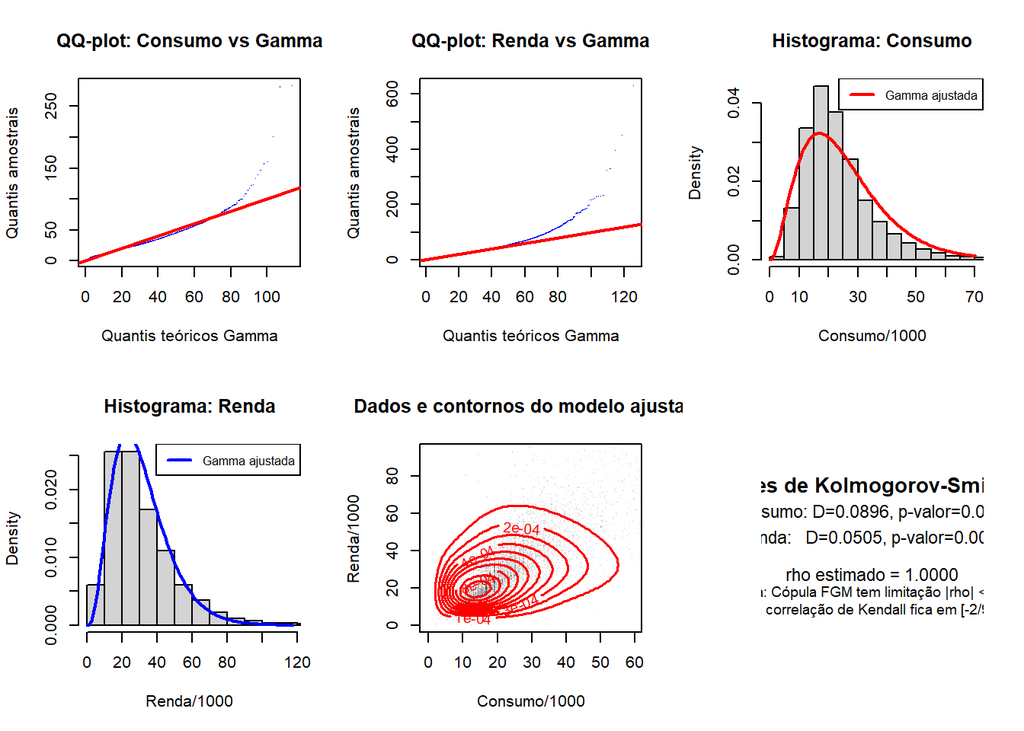

```r
# --- Análise da qualidade do ajuste ---

# 1) Verificação das marginais: QQ-plot contra Gamma ajustada
#pdf("plots_item_c.pdf", width = 14, height = 10)
par(mfrow = c(2, 3))

# QQ-plot marginal X (consumo)
q_x <- sort(x_data)
p_x <- (1:n) / (n + 1)
q_x_theo <- qgamma(p_x, shape = alpha_hat, rate = 1/theta_hat)
plot(q_x_theo, q_x, pch = ".", col = "blue",
     xlab = "Quantis teóricos Gamma", ylab = "Quantis amostrais",
     main = "QQ-plot: Consumo vs Gamma")
abline(0, 1, col = "red", lwd = 2)

# QQ-plot marginal Y (renda)
q_y <- sort(y_data)
q_y_theo <- qgamma(p_x, shape = beta_hat, rate = 1/theta_hat)
plot(q_y_theo, q_y, pch = ".", col = "blue",
     xlab = "Quantis teóricos Gamma", ylab = "Quantis amostrais",
     main = "QQ-plot: Renda vs Gamma")
abline(0, 1, col = "red", lwd = 2)

# 2) Histograma marginal do consumo com densidade ajustada
hist(x_data, breaks = 60, prob = TRUE, col = "lightgray",
     main = "Histograma: Consumo", xlab = "Consumo/1000", xlim = c(0, quantile(x_data, 0.99)))
curve(dgamma(x, shape = alpha_hat, rate = 1/theta_hat), add = TRUE, col = "red", lwd = 2)
legend("topright", "Gamma ajustada", col = "red", lwd = 2, cex = 0.8)

# 3) Histograma marginal da renda com densidade ajustada
hist(y_data, breaks = 60, prob = TRUE, col = "lightgray",
     main = "Histograma: Renda", xlab = "Renda/1000", xlim = c(0, quantile(y_data, 0.99)))
curve(dgamma(x, shape = beta_hat, rate = 1/theta_hat), add = TRUE, col = "blue", lwd = 2)
legend("topright", "Gamma ajustada", col = "blue", lwd = 2, cex = 0.8)

# 4) Scatterplot com contornos do modelo ajustado
x_range <- seq(0.01, quantile(x_data, 0.98), length.out = 80)
y_range <- seq(0.01, quantile(y_data, 0.98), length.out = 80)

z_fit <- outer(x_range, y_range, function(x, y) {
  mapply(pdf_morgenstern, x, y,
         MoreArgs = list(alpha = alpha_hat, beta = beta_hat,
                         theta = theta_hat, rho = rho_hat))
})

plot(x_data, y_data, pch = ".", col = rgb(0, 0, 0, 0.1),
     xlab = "Consumo/1000", ylab = "Renda/1000",
     main = "Dados e contornos do modelo ajustado",
     xlim = range(x_range), ylim = range(y_range))
contour(x_range, y_range, z_fit, nlevels = 15, add = TRUE, col = "red", lwd = 1.5)

# 5) CDF empírica bivariada vs teórica (avaliada em pontos da grade)
# Teste de Kolmogorov-Smirnov para cada marginal
ks_x <- ks.test(x_data, "pgamma", shape = alpha_hat, rate = 1/theta_hat)
ks_y <- ks.test(y_data, "pgamma", shape = beta_hat, rate = 1/theta_hat)
plot.new()
plot.window(xlim = c(0, 1), ylim = c(0, 1))
text(0.5, 0.8, "Testes de Kolmogorov-Smirnov", cex = 1.3, font = 2)
text(0.5, 0.65, sprintf("Consumo: D=%.4f, p-valor=%.4f", ks_x$statistic, ks_x$p.value), cex = 1.1)
text(0.5, 0.50, sprintf("Renda:   D=%.4f, p-valor=%.4f", ks_y$statistic, ks_y$p.value), cex = 1.1)
text(0.5, 0.30, sprintf("rho estimado = %.4f", rho_hat), cex = 1.1)
text(0.5, 0.15, paste("Nota: Cópula FGM tem limitação |rho| <= 1,\n",
                       "mas a correlação de Kendall fica em [-2/9, 2/9]."),
     cex = 0.9)
```

## Execricio 2